# AII 600 midterm problem bank

Extra practice by topic. Fall 2026

**How this page fits.** The [study guide](https://vsokolov.org/courses/files/600/midterm_prep_extended.html) builds each topic from the start. This bank gives you more problems on one topic at a time: 43 problems from the textbook and the labs, each with a solution, all on material the midterm tests. Each section names the midterm problems it practices. When you are ready, sit the [practice midterm](https://vsokolov.org/courses/files/600/midterm-prep.html) under exam conditions. Problem numbers are kept from the earlier version of this bank, so some numbers are skipped.

**The exam.** Wednesday 14 October, in class: 2 hours 30 minutes, 7 problems, 100 points, pen and paper, and one double-sided cheat sheet, printed or handwritten. No calculator, laptop, phone, watch, or AI assistant. The exam’s numbers are chosen so that every calculation is short by hand.

**A calculator is fine here.** Many problems below keep the textbook’s numbers, which need a calculator for the last step. Write the setup by hand, then use a calculator only to finish. The exam itself needs none.

The exam checks that you can use the basic concepts without an assistant, and that you can think about the modelling assumptions those concepts rest on.

This bank covers [Foundations](https://vsokolov.org/courses/files/600/01-intro.html), [Estimation and regression](https://vsokolov.org/courses/files/600/02-estimation-regression.html) through linear regression, and logistic regression from the 7 October class. The problems are from the [textbook](https://vsokolov.org/html/_book/) and the labs. An assumption item may be a printed plot. Name the pattern, name the assumption that failed, and say which way a number you already computed would move.

# Reading guide

The textbook is [Bayes, Artificial Intelligence, and Deep Learning](https://vsokolov.org/html/_book/) (Polson and Sokolov). Read the sections named below. The exam is pen and paper, so skip every Computing block and any derivation whose only job is to justify a formula you will not write. The labs and this bank are how you check that the reading stuck.

You do not need every example. You need the move in the table in the next section: name the concept, write the one-line mechanism, finish the arithmetic, say what it means, and say which way it moves if an assumption changes.

## Weeks 1–3. Foundations

Slides: [Foundations](https://vsokolov.org/courses/files/600/01-intro.html). Labs 1, 2, and 3. Lecture through week 3 stops at the Normal.

[Chapter 1. Probability and Uncertainty](https://vsokolov.org/html/_book/01-prob.html). Read from the opening through Normal: odds as a probability, the hitting streak, random variables, expectation and variance, covariance and linear combinations (Tortoise and Hare), joint / marginal / conditional, independence, Dutch Book, binomial and Normal including the 1987 crash. Skip CDFs, the inverse-CDF sampling section, Kolmogorov’s strong law, and the Computing exercises.

[Chapter 2. Bayes’ Rule](https://vsokolov.org/html/_book/02-bayes.html). Read Bayes’ rule and the law of total probability, the odds form, the prosecutor’s fallacy, the island, Nakamura, Sally Clark, Wald, sensitivity and specificity, Alice’s mammogram. Skip Naive Bayes as a spam classifier, the Obama election simulation, and the Computing exercises.

## Week 4. Estimation

Slides: [Estimation and regression](https://vsokolov.org/courses/files/600/02-estimation-regression.html). Labs 4 and 5.

Chapter 1, CDFs and the quantile. The sampling distribution of $\bar X$: $\mathrm{sd}(\bar X)=\sigma/\sqrt{n}$, and four times the data halves that. Lab 5 is this block, not the regression lab.

[Chapter 11. Pattern Matching](https://vsokolov.org/html/_book/11-pattern.html), Model Estimation through MSE vs MAE: the likelihood, why squared error goes with Normal errors, and square loss versus absolute loss. Stop at penalized likelihood.

## Weeks 5–7. Linear and logistic regression

Slides: [Estimation and regression](https://vsokolov.org/courses/files/600/02-estimation-regression.html) through the log transformation of the PGA earnings, and the logistic regression slides from the 7 October class, through the log loss. Lab 6.

[Chapter 11](https://vsokolov.org/html/_book/11-pattern.html), the rest through Prediction Accuracy for regression; classification metrics are not on the midterm. Skip Complex Functions if it is only neural-net notation.

[Chapter 12. Linear Regression](https://vsokolov.org/html/_book/12-regression.html), through residual analysis, log and power transforms (mammal brain/body, Apple), categorical variables and dummy encoding, and the golf earnings example. Stop at quantile regression and Bayes regression. Skip Orange Juice and Newfood as computing.

[Chapter 13. Logistic Regression](https://vsokolov.org/html/_book/13-logistic.html), through model fitting and log-odds. Stop at the confusion matrix: it, the ROC, the kernel trick, GLMs, and Polya-Gamma are not on the midterm.

Chapters 14 and 16 are not on the midterm.

## Not on the midterm

Do not spend midterm time on [Chapter 3](https://vsokolov.org/html/_book/03-bl.html) (Bayesian learning), [Chapter 4](https://vsokolov.org/html/_book/04-dec.html) (utility, Ellsberg, Allais, Kelly), [Chapter 5](https://vsokolov.org/html/_book/05-ab.html) (A/B tests, hypothesis tests, and confidence intervals), [Chapter 6](https://vsokolov.org/html/_book/06-hyp.html), Chapters 7–10, trees, ridge, or anything in Part 3 (deep learning). The same goes for the Poisson distribution, the method of moments, deriving a maximum likelihood estimate, inverse-CDF sampling, Chapter 12 from quantile regression, and Chapter 13 from the confusion matrix and thresholds. They are part of the course but not of the midterm, so this bank leaves them out.

# What you have to be able to do

Each row is a concept and the use of it. If you cannot do the use on paper, on a problem you have not seen, you do not have the concept yet.

| Concept | What using it looks like |
| --- | --- |
| Complement, mutually exclusive, independence | $P(\text{at least one})$ without adding; $P(A\text{ or }B)=P(A)+P(B)-P(A\text{ and }B)$; when multiplication is good enough and when it is not |
| Joint, marginal, conditional | Finish a table; $P(Y\mid X)$ vs $P(X\mid Y)$; independence as $P(Y\mid X)=P(Y)$ |
| Bayes | Prior, likelihood, posterior. $P(D\mid T)$ is not $P(T\mid D)$ |
| Linear combination | $E(aX+bY)$ always; variance needs the covariance |
| Binomial | Say whether a count is binomial from whether there is a list of independent trials with the same $p$; write $P(X=k)$ for small $n$ |
| Normal | $z=(x-\mu)/\sigma$; a quantile; a left-tail probability |
| CDF | $F(x)=P(X\le x)$; $F(b)-F(a)$; back from $F$ to $P(X=x)$ |
| CLT | $\mathrm{sd}(\bar X)=\sigma/\sqrt{n}$; four times the data halves it; the average can look Normal when one draw does not |
| OLS | Slope as a rate; $\hat y$ at a new $x$; a residual plot as the check, not $R^2$ |
| Dummy variables | $k$ levels, $k-1$ columns; the reference is a choice |
| Logistic | $p=\sigma(x^T\beta)$; $\beta$ is log-odds, not a change in $p$; the log loss charges a confident mistake more |
| Modelling assumption | Name it; why it was used; what would make it false; which way the number moves |

An assumption item is those four sentences. “Independence might not hold” is not an answer.

1. Name the assumption (independence, iid, linear mean, constant variance, Normal tails, $P(\text{data}\mid H)$ known, who is in the sample).
2. Why it was used (independence makes the computation easier; Normal errors make OLS the MLE; the estimate is whatever this sample produced).
3. What in this problem would make it false. For an estimate: is this sample the population you are solving for?
4. Which way the reported number moves, or whether it is still good enough for the purpose. A larger $n$ of the same sample does not fix bias: the centre is in the wrong place. Sally Clark vs a clean shift is the other template: same assumption, two purposes, two verdicts.

# 1. Probability, independence, expectation

From [Foundations](https://vsokolov.org/courses/files/600/01-intro.html) and Lab 1. Book Chapter 1. Midterm Problems 1 and 7.

A probability is a number you will bet at, and it has to add to one when exactly one of the events happens. Independence lets you multiply; that is a modelling choice, not a fact about the world. Expectation always plugs in linearly; variance does not, unless the covariance is zero.

You should be able to: write $P(\text{at least one})$ from the complement (do not add the single-trial probabilities); write $P(A\text{ or }B)=P(A)+P(B)-P(A\text{ and }B)$, and drop the last term only when the events are mutually exclusive; say when the product is good enough (a clean shift) and when it is not (Sally Clark); compute $E(aX+bY)$ and $\mathrm{Var}(aX+bY)$ from means, variances, and one covariance.

## Problem 1. A clean shift

A warehouse scanner misses a package with probability $0.08$. Eight packages pass in a row. Call the shift clean if none are missed.

1. Assuming misses are independent, what is $P(\text{clean shift})$?
2. $P(\text{at least one miss})$ from (a). Do not add $0.08$ eight times.
3. Give one reason consecutive scans are not independent.
4. Why might you still use the independence model for this probability, and name one example from class where multiplying as if independent is not good enough.

**TipSolution**

1. $P(\text{clean})=(0.92)^8\approx 0.513$.
2. $1-(0.92)^8\approx 0.487$. Adding $8\times 0.08=0.64$ double-counts shifts with two or more misses.
3. A jam, a bad label batch, or a lighting change hits several packages in a row. One miss can also mean the next packages are rushed.
4. Independence gives a number we can compute from one rate, and for “how unusual is a clean shift?” that number is close enough. Sally Clark is the counterexample: the court squared $1/8{,}500$ and got about $1/73{,}000{,}000$. The second death, given the first, is about $1/100$, so both is $1/850{,}000$. The squared number is what made the mother look guilty.

## Problem 1B. $P(A\text{ or }B)$

Tonight’s email goes to people who opened last week ($P(A)=0.12$) or who clicked last week ($P(B)=0.05$). Both: $P(A\text{ and }B)=0.03$.

1. Are $A$ and $B$ independent? Compare $P(A\text{ and }B)$ to $P(A)P(B)$.
2. $P(A\text{ or }B)$.
3. If $A$ and $B$ were mutually exclusive, what would $P(A\text{ or }B)$ be? Why is that the wrong number here?

**TipSolution**

1. No. $0.12\cdot 0.05=0.006$, not $0.03$. Independence is the product.
2. $P(A\text{ or }B)=0.12+0.05-0.03=0.14$.
3. $0.12+0.05=0.17$. Mutually exclusive means both cannot happen, so you would add and stop. Here 3% did both, so you have to subtract.

## Problem 2. Dutch Book

Book Chapter 1, Dutch Book and Coherence.

A racetrack analyst quotes $P(\text{Alpha})=0.50$, $P(\text{Beta})=0.35$, $P(\text{Gamma})=0.25$ for a three-horse race. Exactly one horse wins.

1. Which axiom do the quotes violate?
2. Should you buy or sell equal contracts on all three, and what is the sure profit on a $\pm 100$ stake?
3. She revises Gamma to $0.15$. Is the book now coherent?

**TipSolution**

1. Exactly one horse wins, so the three quotes have to add to $1$ (coherence; no Dutch book). They sum to $1.10$.
2. Sell. Take $S=-100$: collect $110$ up front, pay $100$ on whichever horse wins, profit $\$10$ in every world.
3. Yes. The prices now sum to $1$, so there is no sure profit from buying or selling equal amounts on all three.

## Problem 3. A mix of two salespeople

Lab 2 Exercise 2; in-class stop.

You split Saturday’s leads: half to Tortoise, half to Hare. $P=\tfrac12 T+\tfrac12 H$ is the average per rep. $E(T)=E(H)=1.5$, $\mathrm{Var}(T)=0.25$, $\mathrm{Var}(H)=2.25$, $\mathrm{Cov}(T,H)=-0.75$.

Compute $E(P)$ and $\mathrm{Var}(P)$. Compare $\mathrm{Var}(P)$ to $\mathrm{Var}(T)$. What did the covariance do?

**TipSolution**

$E(P)=1.5$.
$$\mathrm{Var}(P)=\tfrac14\cdot 0.25+\tfrac14\cdot 2.25+2\cdot\tfrac12\cdot\tfrac12\cdot(-0.75)=0.0625+0.5625-0.375=0.25.$$
Same mean and same variance as Tortoise alone. Without the covariance you would have $0.625$, worse than Tortoise. Perfect negative correlation is what cancels Hare’s noise.

## Problem 3B. Oil: expected payoff is not the decision

Book Chapter 1, Expectation and Strategy.

An oil company can use a standard drill or a more expensive horizontal drill. Chance of a small / moderate / large find: $0.2$, $0.5$, $0.3$. Payoffs in $millions:

|  | small | moderate | large |
| --- | --- | --- | --- |
| Standard | 20 | 30 | 40 |
| Horizontal | $-20$ | 40 | 80 |

1. Expected payoff and variance for each strategy. Which maximises expected payoff?
2. If a $\$20$ million loss is a problem for the firm, which do you choose, and what assumption about “maximise $E(X)$” just failed?
3. A geological study would reveal the size of the find before you choose the drill. What is the most you should pay for that study? What did you assume about the study?

**TipSolution**

1. Standard: $E=31$, $\mathrm{Var}=49$. Horizontal: $E=40$, $\mathrm{Var}=1200$. Horizontal maximises expected payoff.
2. Standard. Maximising $E(X)$ ranks an expected $31$, whose worst case is $20$, against an expected $40$ that can lose $20$. A $\$20$ million loss is a different cost.
3. With the study you pick standard on small ($20$ beats $-20$), horizontal otherwise: $0.2\cdot 20+0.5\cdot 40+0.3\cdot 80=48$. Willing to pay $48-40=8$ million. You assumed the study is perfect, and that you will actually switch the drill once you see the result.

## Problem 4. True or false

Book Chapter 1, True/False Variance and Expectation. Answer each in one sentence.

1. If $\mathrm{Cov}(X,Y)=0$, then $X$ and $Y$ are independent.
2. If $X$ and $Y$ are independent, $\mathrm{Var}(2X-Y)=2\mathrm{Var}(X)-\mathrm{Var}(Y)$.
3. $E(X+Y)=E(X)+E(Y)$ only if $X$ and $Y$ are independent.
4. $E(\bar X)=\mu$.
5. Correlation lies in $[0,1]$.

**TipSolution**

1. False. Uncorrelated does not imply independent, except in special cases (joint Normal).
2. False. $\mathrm{Var}(2X-Y)=4\mathrm{Var}(X)+\mathrm{Var}(Y)$ under independence.
3. False. Linearity of expectation does not need independence.
4. True.
5. False. Correlation is in $[-1,1]$.

# 2. Joint tables, Bayes, evidence

Lab 2 and the second half of Foundations. Book Chapter 2. Midterm Problems 1 and 2.

A joint table is three distributions in one grid: joint, row/column sums (marginals), and ratios (conditionals). Bayes is the same ratio with names: prior, likelihood, posterior. $P(D\mid T)$ is not $P(T\mid D)$. The prosecutor’s fallacy is reporting the second and calling it the first.

You should be able to: finish a table and read $P(Y\mid X)$ and $P(X\mid Y)$ from different denominators; check independence as $P(Y\mid X)=P(Y)$; update a two-type prior with a binomial likelihood; turn a 2-by-2 of counts into TPR and into $P(D\mid T)$, and say which number Alice needs after a positive.

## Problem 5. Joint table

Book Chapter 1, Joint Distributions. Same move as Lab 2 Exercise 1.

A credit-card book of $10{,}000$ customers:

| bal def | 0 | 1 |
| --- | --- | --- |
| 1 (low) | 8,940 | 64 |
| 2 | 651 | 136 |
| 3 (high) | 76 | 133 |

1. Marginal distribution of `def`.
2. Conditional distribution of `bal` given `def` $=1$.
3. Predict status for a customer with a high balance. Compare to low balance.
4. A product team wants to pitch only to `bal` $=3$ because “that is where the defaults are.” Using the numbers: who does that mix up, and what would you check before restricting the book?
5. Is `def` independent of `bal`? Compare $P(\mathrm{def}=1\mid\mathrm{bal}=1)$ to $P(\mathrm{def}=1)$.

**TipSolution**

1. $P(\mathrm{def}=0)=0.9667$, $P(\mathrm{def}=1)=0.0333$.
2. Given default: $64/333\approx 0.192$, $136/333\approx 0.408$, $133/333\approx 0.399$.
3. $P(\mathrm{def}=1\mid\mathrm{bal}=3)=133/209\approx 0.636$. $P(\mathrm{def}=1\mid\mathrm{bal}=1)=64/9004\approx 0.007$. About ninety times more likely at high balance.
4. The team is mixing $P(\mathrm{bal}\mid\mathrm{def})$ with $P(\mathrm{def}\mid\mathrm{bal})$. Most defaults are not in the high-balance cell in count terms (64 and 136 sit elsewhere); the *rate* is high at `bal` $=3$. Restricting the pitch to high balance misses current customers in bands 1 and 2 and bothers a slice that is only 64% default, not “the defaulters.” Check the purpose: collections vs a wellbeing product are different losses.
5. No. $0.007$ is not $0.033$. Independence would be $P(\mathrm{def}=1\mid\mathrm{bal})=P(\mathrm{def}=1)$ in every row.

## Problem 6. Manchester

Book Chapter 2, Manchester.

Someone in a bar is supporting Manchester United. $P(\text{born within 20 miles})=1/20$. If born there, they support United with probability $7/10$; otherwise $1/10$. What is $P(\text{born there}\mid\text{supports United})$?

**TipSolution**

$$P(B\mid U)=\frac{(7/10)(1/20)}{(7/10)(1/20)+(1/10)(19/20)}=\frac{0.035}{0.130}\approx 0.269.$$
Most United shirts in a typical bar were not born in Manchester.

## Problem 7. Tesla chip

Book Chapter 2, Tesla Chip.

Thirty percent of chips from Matsushita (3% defective), 20% Philips (5%), 50% Hitachi (4%). A chip is defective. Posterior on each manufacturer?

**TipSolution**

$P(D)=0.30\cdot 0.03+0.20\cdot 0.05+0.50\cdot 0.04=0.039$.

$P(\text{Matsushita}\mid D)=9/39$, $P(\text{Philips}\mid D)=10/39$, $P(\text{Hitachi}\mid D)=20/39$.

## Problem 7B. You did not need the incidence

Book Chapter 2, Lung Cancer.

Women who smoke are about 13 times more likely to develop lung cancer than women who do not. In 2016, $17.9\%$ of women smoked.

1. $P(\text{smoker}\mid\text{lung cancer})$. Let $y=0.179$ be the smoking rate and $x$ the rate of lung cancer among nonsmokers. Show that $x$ cancels.
2. Most people guess a number well below $74\%$. What did they treat as the answer instead of $P(\text{smoker}\mid\text{cancer})$?
3. The $13$ is a relative risk from a population. What would make it the wrong likelihood ratio for *this* woman?

**TipSolution**

1. Smokers with cancer are proportional to $13xy$, nonsmokers with cancer to $x(1-y)$. Then
   $$P(S\mid C)=\frac{13y}{13y+(1-y)}=\frac{13\cdot 0.179}{13\cdot 0.179+0.821}\approx 0.74.$$
   The absolute risk $x$ cancels. You needed the relative risk and the smoking rate, not $P(\text{cancer})$.
2. They answered $P(\text{cancer}\mid\text{smoker})$, or the smoking rate $17.9\%$, or “$13$ times more likely so it must be nearly certain.” The question is the other conditional.
3. This woman is not a draw from the CDC table: age, asbestos, a family history, or a clinic that already selected for respiratory disease. Then the $13$ is someone else’s likelihood ratio, and $74\%$ is not her posterior.

## Problem 8. The island

Lab 2 Exercise 4; Book Chapter 2, Island Problem.

A man is arrested on an island of $1{,}001$ people. The crime-scene trait occurs in $1$ in $10{,}000$ people; it matches him. Uniform prior. $P(\text{match}\mid\text{guilty})=1$.

The prosecutor tells the jury: “The match probability is 1 in 10,000, so there is a 99.99% chance he is guilty.”

1. Prior odds he is innocent.
2. Posterior odds of innocence, and $P(\text{guilty}\mid\text{match})$.
3. One sentence to the jury.

**TipSolution**

1. $O(I)=1000/1=1000$.
2. Bayes factor for innocence is $10^{-4}$, so $O(I\mid E)=0.1$. Then $P(I\mid E)=0.1/1.1\approx 0.091$, so $P(G\mid E)\approx 0.91$.
3. The prosecutor reported $1-P(\text{match}\mid\text{innocent})$, not $P(\text{guilty}\mid\text{match})$. Expected matches among the other 1,000 people: $0.1$. That $0.1$ is why the posterior is $0.91$, not $0.9999$, and not a conviction.

## Problem 8B. A match is not a conviction

Book Chapter 2, Forensic Match.

$P(E\mid G)=0.90$, $P(E\mid\text{innocent})=0.02$. Prior $P(G)=1/200$.

1. Bayes factor for a match, posterior odds, and $P(G\mid E)$.
2. A second, conditionally independent eyewitness has Bayes factor $3$. Posterior probability after both?
3. Is $40\%$ enough to convict “beyond a reasonable doubt”? What assumption about the eyewitness would make the $3$ too large?

**TipSolution**

1. $\mathrm{BF}=0.90/0.02=45$. Prior odds $1/199$. Posterior odds $45/199\approx 0.226$, so $P(G\mid E)=45/244\approx 0.184$.
2. $O=3\times 45/199=135/199$, $P=135/334\approx 0.404$.
3. No. A $45\times$ match and a $3\times$ witness still leave the prior in charge. If the eyewitness is more likely to pick the person who already matched (not conditionally independent given guilt), you multiplied a Bayes factor you did not have. Same machine as the island and Nakamura.

## Problem 9. A closer

Lab 2 Exercise 6.

Half the bootcamp convert 70% of qualified leads, half convert 30%. First week: 3 closes out of 4. Equal priors.

1. Likelihood ratio $P(\text{3 of 4}\mid 70\%)/P(\text{3 of 4}\mid 30\%)$.
2. $P(\text{70\% closer}\mid\text{3 of 4})$.
3. One sentence to the sales manager: put them on the enterprise book, or is four leads still “too small to say”?

**TipSolution**

1. The $\binom{4}{3}$ cancels: $0.7^2/0.3^2\approx 5.44$.
2. $5.44/(1+5.44)\approx 0.845$.
3. Four leads moved you from 50% to 85%. That is not “too small to say.” The enterprise book is a 15% chance you just promoted the 30% closer. Say that, then decide.

## Problem 9B. Likelihoods you treated as known

Lab 2 Exercise 7, written part. The arithmetic is in the lab; this is the assumption.

New products have high sales 8% of the time. If sales are high, a focus group is positive 70% of the time; if low, 15%. You treat those two numbers as $P(\text{Pos}\mid H)$ and $P(\text{Pos}\mid L)$, then report $P(H\mid\text{Pos})\approx 0.29$.

1. What two distinct things can go wrong when you take focus-group reactions as $P(\text{Pos}\mid H)$? Who is in the room is one class of problem; what people say versus what they do is another.
2. If the people who show up are already more enthusiastic than the market, which of $P(\text{Pos}\mid H)$ and $P(\text{Pos}\mid L)$ moves, and what happens to $P(H\mid\text{Pos})$?
3. The 8% is the number to beat. Is 29% a launch? What would you need to know about the cost of a failed launch versus a missed hit?

**TipSolution**

1. The room is not the market: volunteers, staff, or a city that already likes the category. And a stated “I would buy” is not a sale. Either way you have estimated a different likelihood than the one the posterior needs.
2. Both likelihoods of a positive reaction go up if the room is more enthusiastic than the market. The likelihood ratio $P(\text{Pos}\mid H)/P(\text{Pos}\mid L)$ can rise or fall; if the low-sales group becomes almost as positive as the high-sales group, the Bayes factor shrinks and $P(H\mid\text{Pos})$ falls toward the 8% prior. The usual failure is that a positive stops distinguishing.
3. 29% is not a launch on its own. A failed launch that is costly relative to a missed hit wants a higher posterior than 29%; a cheap test with a large upside can live with 29%. The 8% is the prior, not the decision.

## Problem 10. Mammogram

Lab 2 Exercise 8; Alice in lecture.

Prevalence 1%, detection rate 80%, false-positive rate 10%. In 1,000 people like Alice: 10 have cancer, 8 true positives, 99 false positives, 2 false negatives, 891 true negatives.

1. TPR, FNR, FPR, TNR from the 2-by-2.
2. $P(\text{cancer}\mid\text{positive})$.
3. A radiologist says “the test is 80% accurate.” Which of your four rates is that, and why is it not the number Alice needs after a positive?

**TipSolution**

1. $\mathrm{TPR}=8/10=0.8$, $\mathrm{FNR}=0.2$, $\mathrm{FPR}=99/990=0.1$, $\mathrm{TNR}=0.9$.
2. $8/(8+99)=8/107\approx 0.075$.
3. “80% accurate” is sensitivity, $P(T\mid D)$. Alice needs $P(D\mid T)\approx 7.5\%$. Most positives are the 99 false alarms from the 990 without cancer.

## Problem 10B. Should Nvidia use the test?

Book Chapter 2, Sensitivity and Specificity.

A chip is defective with probability $0.1\%$. The test always flags a defective chip, and flags a good chip with probability $1\%$.

1. Sensitivity and specificity.
2. $P(\text{defective}\mid\text{flagged})$ and $P(\text{flagged})$.
3. Advise Nvidia whether to scrap every flagged chip. What loss did you just use, and what would flip the advice?

**TipSolution**

1. Sensitivity $1$, specificity $0.99$.
2. $P(D\mid T)=0.001/(0.001+0.01\cdot 0.999)\approx 0.091$. About $1.1\%$ of chips are flagged.
3. Do not scrap them all: $91\%$ of flags are good chips. That advice assumes a good chip is costly to throw away relative to a defective one that ships. Flip it if a defective chip in the wild is catastrophic (a recall, a car) compared with the cost of a spare: then flag-and-retest, or a second test on the $1.1\%$, rather than “the sensitivity is 100% so ship only the negatives.”

## Problem 10C. Eight tests, one rider

Book Chapter 2, Floyd Landis.

Landis gave eight urine samples. Specificity $95\%$. Treat the eight tests as independent given innocence.

1. $P(\text{all eight negative}\mid\text{innocent})$. Then $P(\text{at least one positive}\mid\text{innocent})$.
2. What did independence do, and why might consecutive samples from one rider not be independent?
3. In court, is “at least one positive” under independence a probability of guilt? What else do you need?

**TipSolution**

1. $0.95^8\approx 0.663$, so $P(\text{at least one FP}\mid\text{innocent})=1-0.95^8\approx 0.337$.
2. Independence lets you raise $0.95$ to the 8th. One lab, one rider, one stage: a contaminated kit or a lab shift hits several samples together. Then $P(\text{at least one FP})$ is closer to $0.05$ than to $0.34$.
3. No. That is $P(E\mid\text{innocent})$, the prosecutor’s number. You still need a prior and $P(E\mid\text{guilty})$. Eight opportunities inflate the chance of a flag under innocence; they do not, by themselves, convict.

## Problem 10D. The prior moved

Book Chapter 2, Breathalyzer Test.

Sensitivity $99\%$, specificity $90\%$, prior that the driver is over the limit $10\%$.

1. $P(\text{over}\mid\text{positive})$.
2. At Christmas the prior is $20\%$. Same posterior?
3. The device did not change. What did, and for a checkpoint that tests everyone, which prior is the right one?

**TipSolution**

1. $0.99\cdot 0.10/(0.99\cdot 0.10+0.10\cdot 0.90)=0.099/0.189\approx 0.524$.
2. $0.99\cdot 0.20/(0.198+0.10\cdot 0.80)=0.198/0.278\approx 0.712$.
3. The base rate. A random checkpoint uses the population prior (10% on an ordinary night, 20% at Christmas). A stop after weaving is a different prior, and the $52\%$ is the wrong number for that stop.

## Problem 11. Alarm, explaining away

Lab 3 Exercise 1.

$p(b)=2\cdot 10^{-4}$, $p(e)=10^{-2}$, $p(r=1\mid e=1)=0.5$, $p(r=1\mid e=0)=0$, and

| $p(a=1\mid b,e)$ | $b$ | $e$ |
| --- | --- | --- |
| 0 | 0 | 0 |
| 0.1 | 0 | 1 |
| 1 | 1 | 0 |
| 1 | 1 | 1 |

1. $P(a=1\mid b=0)$ and $P(b=1\mid a=1)$. The second is Bayes with two causes.
2. Same posterior if $p(b)=10^{-3}$. What did raising the prior do?
3. The radio reports a small earthquake. Does $P(b=1\mid a=1,r=1)$ go up or down from $P(b=1\mid a=1)$? Why, in two sentences, and why is that not “the alarm was a false positive”?

**TipSolution**

1. $P(a=1\mid b=0)=0.1\cdot 0.01=0.001$. Then
   $$P(b=1\mid a=1)=\frac{2\cdot 10^{-4}}{2\cdot 10^{-4}+0.001\cdot(1-2\cdot 10^{-4})}\approx 0.167.$$
2. About $0.50$. A larger prior on burglary, with the same likelihood, raises the posterior. That is Bayes, not a new alarm model.
3. Down. The radio is an alternative cause of the same alarm (explaining away). The sensor still sounded; burglary is just no longer the remaining explanation.

## Problem 12. Holes you can see

Lab 2 Exercise 3; Wald.

316 planes returned. Cockpit: 36 returned, 21 down. Engine: 29 returned, 31 down. Someone counted 36 cockpit holes on the planes that came back and wants cockpit armor.

1. Among the planes you can see, how common is cockpit damage?
2. Among planes that took a cockpit hit, how often did the plane come back? Same question for engine.
3. Which of those numbers goes in the brief? One sentence on what $36/316$ is actually describing.

**TipSolution**

1. $36/316\approx 0.114$.
2. Cockpit: $36/57\approx 0.63$ came back. Engine: $29/60\approx 0.48$.
3. Armor goes where returning was rare given the hit. The 11% is holes on the planes you can see. The 63% vs 48% is the decision.

# 3. Binomial and Normal

Labs 3 and 4, and the last block of Foundations. Book Chapter 1, named distributions. Midterm Problems 3 and 4.

A binomial is a list of independent yes/no trials. A Poisson is a count with a rate and no such list. The Normal is a location and a scale; a $z$-score is a change of units. $P(X\le x)=\Phi((x-\mu)/\sigma)$. A large count can borrow the bell.

You should be able to: say from the story whether a count is binomial; write $P(X=k)$ for $n=4$ by hand; standardise a Normal and read a tail or a quantile; say which way a tail probability moves if the left tail is heavier than the bell; read a histogram against a fitted density and say where the model is lying.

## Problem 13. Name the count

Lab 3 Exercise 2.

For each, say Binomial or Poisson, and why.

1. 80 independently tested circuit boards. $X=$ number that fail.
2. Cardiac-arrest calls to 911 between midnight and 6am.
3. A subscriber is shown 12 thumbnails. $X=$ number they click. Each click independent with the same $p$.
4. Goals Hull scores against Man U on Saturday.

**TipSolution**

1. Binomial: a list of 80 independent yes/no trials.
2. Poisson: a rate, no list of trials.
3. Binomial: 12 independent clicks.
4. Poisson: a rate of goals, not 90 independent minute-trials with a fixed $p$.

## Problem 14. Four at-bats

Lab 3 Exercise 3, first number. Lecture self-check.

Joe DiMaggio, $p=0.325$ per at-bat. Treat four at-bats as independent Bernoulli trials.

1. Name the distribution of $X=$ hits in a game.
2. Write $P(X>2)$ as two binomial terms, then compute it. Do not paste $0.104$ from a slide.
3. What did independence do for you, and what would a hit raising the next $p$ do to this probability?

**TipSolution**

1. $X\sim\mathrm{Binomial}(4,0.325)$.
2. $P(X=3)+P(X=4)=\binom{4}{3}(0.325)^3(0.675)+(0.325)^4\approx 0.0927+0.0112=0.104$.
3. Independence lets the pmf factor. A hit raising the next $p$ raises $P(X>2)$: the mass on 3 and 4 hits moves up relative to the independent calculation. The 56-game streak is this 10% stacked, not a typical night.

## Problem 16. Warranty

Lab 4 Exercise 1.

Life $L\sim N(10,3^2)$ years. The warranty pays if $L<5$. A shipment has 80 independent components.

1. $p=P(L<5)$. Write the $z$-score. Name the distribution of $X=$ number of claims in the shipment, and write $E(X)$.
2. If lives have a heavier left tail than this Normal, which way does $E(X)$ move? Which of the two models did you change, and which did you keep?

**TipSolution**

1. $z=(5-10)/3=-5/3\approx -1.67$, so $p=\Phi(-1.67)\approx 0.048$. $X\sim\mathrm{Binomial}(80,p)$, $E(X)=80p\approx 3.8$.
2. A heavier left tail raises $p$, so $E(X)$ rises. You changed the model for $L$. The binomial layer that turns $p$ into a count is the same.

## Problem 17. A month in the book

Lab 4 Exercise 2.

Monthly return $X\sim N(0.008,0.035^2)$.

1. $P(X<-0.08)$.
2. $z$-score of a $-12\%$ month.
3. The $1\%$ quantile of $X$.
4. The officer wants $P(X<-0.08)=0.05$ without changing the mean. What $\sigma$ would that take? Use $\Phi^{-1}(0.05)\approx -1.645$, not $1.96$.
5. The 1987 crash was a 5-sigma month under a Normal fitted to earlier data. Is $P(X<-0.08)$ under the Normal too small, too large, or could it go either way?

**TipSolution**

1. $z=(-0.08-0.008)/0.035=-2.51$, so $P\approx 0.006$.
2. $z=(-0.12-0.008)/0.035\approx -3.66$.
3. $q=0.008+0.035\cdot\Phi^{-1}(0.01)\approx -0.073$.
4. $(-0.08-0.008)/\sigma=-1.645$ gives $\sigma\approx 0.0535$. The book’s $0.035$ is too tight if a probability of $0.05$ for an $8\%$ decline is the risk the officer wants to price.
5. A heavier-tailed histogram than the bell makes far-left probabilities larger than the Normal says, so $0.006$ is too small. That is the crash lesson, not a maybe.

## Problem 17B. The histogram is not a bell

Lecture: Normal tails; Lab 4 Exercise 2. Same monthly returns as Problem 17, now as a picture.

The histogram is 80 months. The dashed curve is $N(0.008, 0.035^2)$, the model from Problem 17, scaled to the same bins.

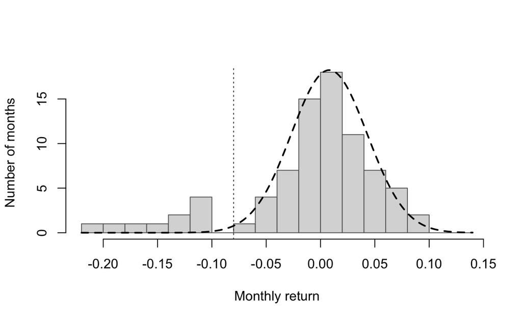

Monthly returns. Histogram of 80 months; dashed curve is the Normal used in Problem 17, scaled to the same bins.

1. Where does the histogram disagree with the dashed curve? (The dotted vertical line is $-8\%$, the event in Problem 17a.)
2. Is $P(X<-0.08)\approx 0.006$ from the Normal too small, too large, or could it go either way?
3. Collecting 800 months instead of 80, still from this world, would make the histogram look more like the dashed curve. True or false, and what did you just assume?

## Problem 18. A large count

Lab 4 Exercise 3.

$n=400$ people, each buys independently with $p=0.12$. $X=$ number who buy.

1. Name the distribution of $X$. Write $E(X)$ and $\mathrm{sd}(X)$.
2. Using the Normal with that mean and sd, $P(X\ge 60)$ is $P(Z\ge ?)$. What is the $z$? You may leave the tail as $1-\Phi(z)$.
3. Why is a Normal even in the conversation? The $X_i$ are 0–1.

**TipSolution**

1. $X\sim\mathrm{Binomial}(400,0.12)$. $E(X)=48$, $\mathrm{sd}(X)=\sqrt{400\cdot 0.12\cdot 0.88}=\sqrt{42.24}\approx 6.50$.
2. $z=(60-48)/6.50\approx 1.85$. $P\approx 1-\Phi(1.85)$.
3. CLT: a sum of many independent Bernoulli trials is approximately Normal. The binomial is already that sum. You are not claiming each person is Normal.

# 4. The CDF, the likelihood, and the average

[Estimation and regression](https://vsokolov.org/courses/files/600/02-estimation-regression.html). Book Chapters 1.4, 1.6, and 11.4. Midterm Problems 3, 4, 5, and 6.

A CDF accumulates a distribution: $F(x)=P(X\le x)$, and differences of $F$ give the probabilities back. The likelihood is the probability of the data you saw, as a function of the parameter; least squares and the log loss both come from it. The average of $n$ independent draws has standard deviation $\sigma/\sqrt{n}$, and the CLT is why it looks Normal even when one draw does not.

You should be able to: read $F(x)$ and $F(b)-F(a)$, and turn a CDF back into $P(X=x)$; write the likelihood of 0/1 data and connect it to the log loss; say what happens to $\mathrm{sd}(\bar X)$ if $n$ quadruples.

## Problem 19. CDF and a leftover delivery

Book Chapter 1, Conditional Probability (delivery times).

Delivery day $X\in\{1,\ldots,7\}$ with CDF

| $x$ | 1 | 2 | 3 | 4 | 5 | 6 | 7 |
| --- | --- | --- | --- | --- | --- | --- | --- |
| $P(X\le x)$ | 0.10 | 0.20 | 0.70 | 0.75 | 0.80 | 0.90 | 1 |

1. Fill $P(X=x)$.
2. $P(X=4\mid X\ge 4)$.

**TipSolution**

1. Differences of the CDF: $0.10,0.10,0.50,0.05,0.05,0.10,0.10$.
2. $P(X=4\mid X\ge 4)=0.05/(1-0.70)=0.05/0.30=1/6$.

## Problem 19B. Read $F$

Lab 5 Exercise 1. Lecture: eight calls, then the die.

Eight calls took $0.4, 0.6, 0.9, 1.1, 1.5, 1.8, 2.4, 3.1$ seconds. The timeout is 2 seconds. $F(x)=P(X\le x)$.

1. Empirical $F(2)$ from these eight calls.
2. A model says the next call is $\mathrm{Uniform}(0,4)$, so $F(x)=x/4$ on $[0,4]$. What is $F(2)$ under the model? The sample said $0.75$ and the model says $0.50$. Which number is for the next call, and what did you assume about these eight?
3. A fair die. $F(2)$, $F(4)$, and $F(4)-F(2)$. Does that difference include a 2? What is $P(2\le X\le 4)$?

**TipSolution**

1. Six of the eight times are at most 2, so $F(2)=6/8=0.75$.
2. $F(2)=2/4=0.5$. The $0.75$ describes these eight calls. The $0.50$ is the next call only if the next one is a draw from $\mathrm{Uniform}(0,4)$. A continuous model also has $P(X=2)=0$, even though $F(2)$ is not zero.
3. $F(2)=2/6$, $F(4)=4/6$, $F(4)-F(2)=2/6$. That is $2<X\le 4$: the jump at 2 sits in $F(2)$, so it is not in the difference. $P(2\le X\le 4)=3/6$.

## Problem 21. Bernoulli likelihood

Book Chapter 11, MLE for Bernoulli.

$y_1,\ldots,y_n\in\{0,1\}$, $P(Y=1)=\theta$.

1. Likelihood $L(\theta)$.
2. Log-likelihood $\ell(\theta)$.
3. Write $-\ell(\theta)$ for a single observation $y$. Where have you met it before?

**TipSolution**

1. $L(\theta)=\theta^{\sum y_i}(1-\theta)^{n-\sum y_i}$.
2. $\ell(\theta)=\sum y_i\log\theta+(n-\sum y_i)\log(1-\theta)$.
3. $-y\log\theta-(1-y)\log(1-\theta)$: the log loss of predicting $\theta$ for an observation $y$. Summed over the data it is $-\ell(\theta)$, so minimizing the total log loss is the same as maximizing the likelihood. That is how logistic regression is fitted.

## Problem 23B. The average, not the call

Lab 5 Exercise 4. Lecture: standard error falls with $\sqrt{n}$.

Hold times are Exponential with mean 2 minutes, so one hold has $\sigma=2$ and a long right tail. The dashboard pages when the average of the last $n$ holds exceeds 2.5 minutes. Nothing is wrong with the line.

1. $\mathrm{sd}(\bar X)$ at $n=5$, $n=20$, and $n=80$. What does going from 20 to 80 do to that standard error?
2. Treat the average of 80 holds as $N(2,\sigma^2/80)$. Write $P(\bar X>2.5)$ as $1-\Phi(z)$ and give $z$.
3. One hold time is not Normal. Why is the Normal in (b) still the right picture at $n=80$, and where would you refuse it?

**TipSolution**

1. $2/\sqrt{5}\approx 0.89$, $2/\sqrt{20}\approx 0.45$, $2/\sqrt{80}\approx 0.22$. From 20 to 80 is four times the data, so the standard error is cut in half.
2. $z=(2.5-2)/(2/\sqrt{80})=\sqrt{80}/4\approx 2.24$. $P\approx 1-\Phi(2.24)$.
3. The CLT is about the average, not about one Exponential draw. At $n=80$ the histogram of averages is close to that Normal; at $n=5$ the skew is still there and the Normal page rate is the wrong picture.

# 5. Linear regression

[Estimation and regression](https://vsokolov.org/courses/files/600/02-estimation-regression.html), through the log transformation of the PGA earnings. Book Chapter 12, up to residual analysis and log-log. Midterm Problems 5 and 7.

The model is $E(y\mid x)=\beta_0+\beta_1 x$ (or more columns). OLS picks $\beta$ to minimise squared residuals. The slope is a rate: the change in predicted $y$ for a one-unit change in $x$. A log-log fit is the same model after a log-log transform, $y=ax^b$. Dummy variables: $k$ levels need $k-1$ columns; the omitted level is the reference, and that is a choice.

$R^2$ answers a narrow question. It is not “is this model good.” A residual plot is the check.

You should be able to: interpret $\hat\beta_1$ and form $\hat y$ at a new $x$; say what a curved mean, non-constant variance, or an outlier in $e$ vs $\hat y$ means; turn $y=ax^b$ into a linear equation in logs and interpret $b$; say what happens to fitted values if you change the dummy reference; look at a scatter of two groups and say what a single line is averaging.

## Problem 24. OLS and a residual plot

Book Chapter 12, Residual Analysis and OLS Derivation (d).

```
lm(price ~ sqft)     # price in $1000s

(Intercept)  50.23    (se 12.35)
sqft          0.1234  (se 0.0089)
Residual se  45.67 on 98 df
R-squared     0.662
```

1. Interpret the slope in dollars per square foot.
2. Predicted price for a 2,000 sq ft house.
3. For simple regression, $\hat\beta_1=S_{xy}/S_{xx}$. What does that say $\hat\beta_1$ is made of?
4. A residual plot against fitted values shows a clear parabola. What would you do, and why is $R^2=0.66$ not an argument to keep the linear model?

**TipSolution**

1. Each additional square foot is associated with $\$123.40$ in predicted price.
2. $50.23+0.1234\cdot 2000=297.03$ thousand, about $\$297{,}000$.
3. It is the sample covariance of $x$ and $y$ over the sample variance of $x$. The slope is a scaled association, not a causal claim.
4. A parabola in the residuals means the linear mean is wrong. Add a square, or log $y$, or log-log, and look at the new residuals. $R^2=0.66$ can be large while the mean is still bent; $R^2$ does not see the pattern in $e$ vs $\hat y$.

## Problem 24B. Who is in the sample

The same `price ~ sqft` fit is on 100 houses that *sold* last year.

1. Name two modelling assumptions besides “the mean is linear in sqft.”
2. Houses that did not sell are missing. If unsold houses are larger and overpriced, which way is $\hat\beta_1$ pulled relative to the slope for *listed* houses?
3. You will use $\hat y$ to advise a seller on asking price. What would have to be true for that use, and what would make you refuse?

**TipSolution**

1. The 100 sales are like draws from the population you care about (iid). Errors have constant variance. sqft is not standing in for omitted size-correlates (lot, school, renovation) that you will not have at prediction time.
2. Large unsold houses sit above the sold cloud in asking price but never enter $y$. The sold line is fitted only on houses whose price was accepted. That usually flattens or tilts the sold slope relative to listed asking prices: you see completed trades, not the full asking curve. The direction to write: $\hat\beta_1$ is a slope among *accepted* prices, so it is not the slope of list price on sqft.
3. The advice is for a house that will sell on the same market as last year’s sales. Refuse if the house is in a different segment (new build, distressed, a size outside the 100) or if the residual plot already said the linear mean is wrong. The $R^2$ does not settle this.

## Problem 24C. MSE or MAE

Book Chapter 11, MSE vs MAE.

Predictions $\hat y=(2,3,4,5,20)$, actual $y=(2,4,4,6,6)$.

1. MSE and MAE.
2. Which metric did the $20$ dominate, and what assumption about the cost of error is MSE making?
3. For house prices, when would you report MAE rather than OLS?

**TipSolution**

1. Errors $y-\hat y$: $0,1,0,1,-14$. $\mathrm{MSE}=(0+1+0+1+196)/5=39.6$. $\mathrm{MAE}=(0+1+0+1+14)/5=3.2$.
2. MSE. Squaring treats a $14 miss as 196 times a $1 miss. That is the right loss if big misses are disproportionately costly (and if you believe the Normal likelihood, which is the same square).
3. When a few mansions or data errors should not own the fit: listing prices, a median asking price, or when the residual plot already shows a heavy tail. OLS/MSE is the default only if that square is the loss you actually have.

## Problem 24D. Four residual plots

Book Chapter 12, Residual Analysis (d); lecture PGA and mammal residual checks.

Each panel is residuals against fitted values from `lm(y ~ x)` on $n=80$ points. The same axes labels on all four.

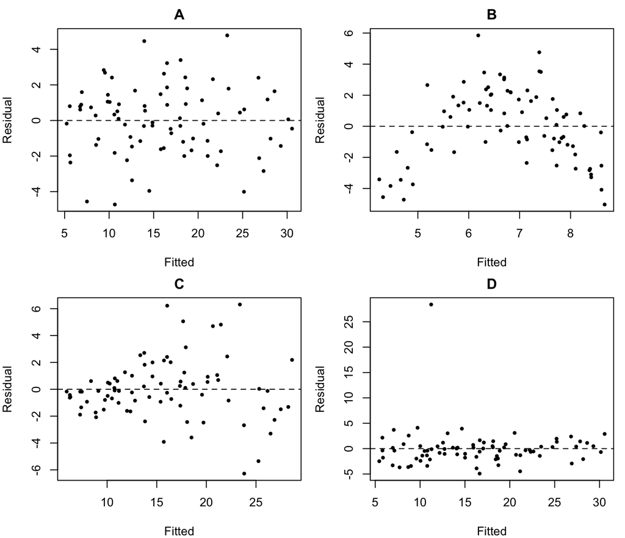

Residuals versus fitted values. Four different data-generating stories, one linear fit each.

1. For each panel, name the pattern in one phrase (none / curved mean / non-constant variance / one outlier).
2. Which modelling assumption of OLS failed in B, in C, and in D? (A is the control.)
3. You need a price at $x=8$. In which panel do you refuse the linear $\hat y$, and in which do you keep the line but change the loss or how you talk about uncertainty?

**TipSolution**

1. A none (random scatter around 0). B curved mean (a U or parabola). C non-constant variance (spread grows with fitted). D one large positive residual.
2. B: $E(y\mid x)$ is not linear in $x$. C: constant variance. D: least squares / MSE treats that point as an ordinary miss; it is not. A is the case where those three are still plausible.
3. Refuse B: the line is the wrong mean, so $\hat y$ at $x=8$ is systematically off. Keep the line in C and D only with a change of use: in C report a spread that grows with $x$, or transform; in D use MAE, or drop a data error after you have named it, rather than let one point own $\hat\beta$. $R^2$ is not in any of the four pictures, and would not have told B from A.

## Problem 25. Log-log as a power law

Book Chapter 12, Log Transformations. Same move as mammal brain/body and Apple growth in lecture.

Advertising $x$ and revenue $y$ (both in $millions) follow $y=ax^b$. Data: $(x,y)=(1,5),(2,8),(4,14),(8,25),(16,45)$.

A log-log fit gives $\log y=1.564+0.798\log x$ (natural logs).

1. Transform the power law to a linear model.
2. What are $\hat a$ and $\hat b$? Interpret $b$.
3. Predict revenue at $x=10$.
4. Why might you prefer this to OLS of $y$ on $x$ in the original scale, even if the raw $R^2$ looks fine?

**TipSolution**

1. $\log y=\log a+b\log x$.
2. $\hat b=0.798$, $\hat a=e^{1.564}\approx 4.78$. A 1% increase in advertising is associated with about a 0.80% increase in revenue: diminishing returns. Doubling $x$ multiplies $y$ by $2^{0.798}\approx 1.74$, not $2$.
3. $\hat y=4.78\cdot 10^{0.798}\approx 30.0$ million.
4. The original scale is multiplicative and the residual spread usually grows with $x$. Log-log makes the mean linear and often gives constant variance. $R^2$ on the raw scale is not comparable to $R^2$ on the log scale, and a high raw $R^2$ can hide the non-constant variance.

## Problem 25B. Two scatters, same $n$

Book Chapter 12, Log Transformations; lecture mammal brain/body and Apple.

Advertising $x$ and revenue $y$, 60 campaigns. Left: $y$ against $x$ with the OLS line. Right: $\log y$ against $\log x$ with its OLS line.

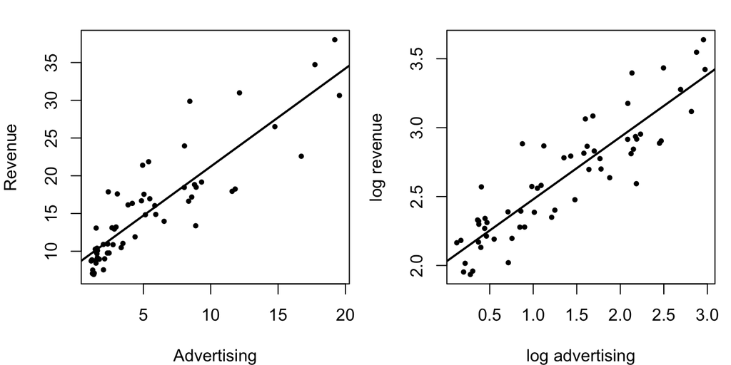

Left: revenue against advertising, linear fit. Right: the same campaigns after a log-log transform.

1. What does the left plot say about $E(y\mid x)$ and about $\mathrm{Var}(y\mid x)$?
2. Why is the right plot the *same* power-law model after a log-log transform, not a different theory of revenue?
3. The left-hand $R^2$ is large. Is that an argument to keep the linear model?

**TipSolution**

## Problem 26. Dummy variables

Lecture: $k$ levels, $k-1$ columns.

A house has `style` $\in\{\text{colonial}, \text{ranch}, \text{split}\}$. You fit
$$\mathrm{price}=\beta_0+\beta_1\mathrm{sqft}+\beta_2\mathbf{1}_{\mathrm{ranch}}+\beta_3\mathbf{1}_{\mathrm{split}}+\varepsilon.$$

1. Why not three style dummies plus an intercept?
2. What is $\beta_2$? What house is $\beta_0+\beta_1\mathrm{sqft}$ describing?
3. You recode and drop `ranch` instead of `colonial`. Which fitted values change? Which coefficients change?

**TipSolution**

1. You cannot put three style columns and an intercept into a sum: every house is colonial or ranch or split, so the three 0/1 columns add to 1. That is why you need $k-1$ columns. The omitted style is the reference.
2. $\beta_2$ is the difference in expected price between ranch and colonial, at the same sqft. The intercept line is colonial.
3. Fitted values do not change. If you change the reference, every coefficient changes and the fitted values do not. You cannot compare $\beta_2$ across the two fits without translating.

## Problem 26B. Two clouds, one line

Lecture dummy variables; same house-price setting as Problem 26.

Left: ranch and colonial on the same scatter, one OLS line through all 80 houses. Right: the same points, two parallel lines (one intercept per style, common slope on sqft).

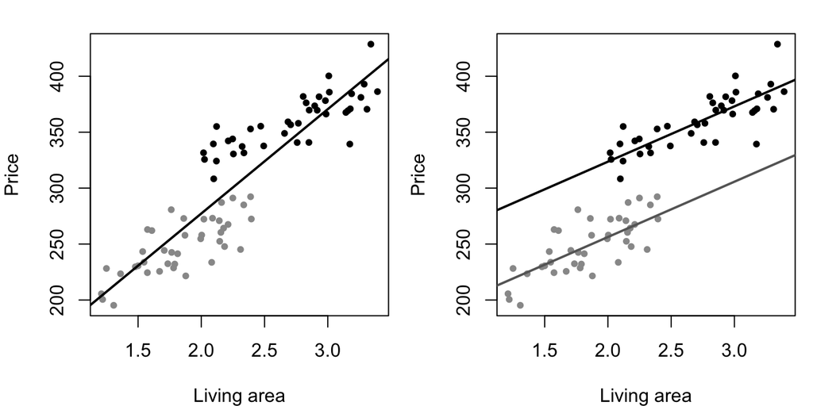

Price against living area. Grey: colonial. Black: ranch. Left: one line. Right: two intercepts, common slope.

1. What is the single line on the left averaging, and why is that slope the wrong rate for a ranch?
2. What did the dummy do on the right that the left plot could not?
3. You will quote $\hat\beta_{\mathrm{sqft}}$ to a seller. Which plot’s slope do you send, and what would make you refuse even the right-hand picture?

**TipSolution**

1. It is a compromise between two clouds that sit in different parts of the sqft range. Ranch is larger and more expensive, so the pooled line climbs from colonial on the left to ranch on the right. The dollars-per-square-foot on the left is partly a style mix, not a size effect.
2. It let the intercept jump for ranch and kept a common slope. The vertical gap is $\beta_{\mathrm{ranch}}$, the number Problem 26 asked for.
3. Send the right-hand slope, with the style named. Refuse if the two clouds are not parallel (style changes the rate, not just the intercept), if “ranch” is standing in for lot or school, or if this house is not in the same market as these 80 sales. Same sample warning as 24B.

## Problem 27. True or false, linear regression

Book Chapter 12, True/False: Linear Regression. Also Book Chapter 11, MSE vs MAE (c)–(d).

1. OLS minimises the sum of absolute residuals.
2. If $y_i=x_i^T\beta+\varepsilon_i$ with iid Normal errors, MLE for $\beta$ is OLS.
3. MAE is more affected by a single huge residual than MSE is.

**TipSolution**

1. False. OLS is squared residuals. Absolute residuals are MAE.
2. True. The Normal log-likelihood is $-\frac{1}{2\sigma^2}\sum(y_i-x_i^T\beta)^2$ plus a constant.
3. False. MSE squares the residual; the outlier dominates MSE more than MAE.

# 6. Logistic regression

The logistic regression slides from the 7 October class, through the log loss. Book Chapter 13, pen and paper. Midterm Problem 6.

$p=\sigma(x^T\beta)$ is a probability in $(0,1)$. The coefficient is a change in log-odds, not in $p$. The log loss, $-y\log p-(1-y)\log(1-p)$, charges a confident mistake far more than a hesitant one.

You should be able to: turn $x^T\beta$ into $p$ with $\sigma$; say what a coefficient changes, and interpret $e^{\beta}$ as an odds ratio; compute the log loss of a prediction. This bank has one log loss item (Problem 21c); for more, use [section 9 of the study guide](https://vsokolov.org/courses/files/600/midterm_prep_extended.html#logistic) and Problem 6 of the [practice midterm](https://vsokolov.org/courses/files/600/midterm-prep.html).

## Problem 28. From log-odds to a probability

Book Chapter 13, Sigmoid. You need the function, not a derivative.

$\sigma(z)=1/(1+e^{-z})$. A fitted log-odds is $z=-0.5+0.4x$.

1. What is $p$ at $x=0$? At $x=0$, what does $z=0$ mean when it occurs?
2. Show, in one line, that $\sigma(-z)=1-\sigma(z)$. Why does that matter for a “no event” probability?
3. If $x$ increases by 1, what happens to the odds? To $p$? (The second answer is not a constant.)

**TipSolution**

1. $z=-0.5$, $p=\sigma(-0.5)\approx 0.378$. $z=0$ means $p=1/2$, a coin flip under the model, which here is at $x=0.5/0.4=1.25$, not at $x=0$.
2. $1-\sigma(z)=e^{-z}/(1+e^{-z})=\sigma(-z)$. $P(\text{no event})=1-p=\sigma(-z)$.
3. Odds are multiplied by $e^{0.4}\approx 1.49$. Probability follows the sigmoid, so the same $+0.4$ in log-odds moves $p$ a lot near $0.5$ and almost not at all near $0$ or $1$.

## Problem 29. Log-odds

Book Chapter 13, Log-Odds Interpretation.

$$\log\frac{p}{1-p}=-1.5+0.8\,\mathrm{usage}-2.0\,\mathrm{annual}.$$
`annual` $=1$ for an annual contract, $0$ for month-to-month. Usage in hours.

1. $P(\text{churn})$ for 5 hours, month-to-month.
2. Odds ratio for switching to annual, usage held fixed.
3. How much would usage need to rise to double the odds of churning?
4. A product manager hears “annual cuts churn by 2.0.” What did they mix up, and what sentence would you send instead?

**TipSolution**

1. Log-odds $= -1.5+4=2.5$, $p=\sigma(2.5)\approx 0.924$.
2. $e^{-2}\approx 0.135$. Annual multiplies the odds of churn by $0.135$, an 86% reduction in *odds*, not a 2-point drop in probability.
3. $e^{0.8\Delta}=2$ gives $\Delta=\log 2/0.8\approx 0.87$ hours.
4. $-2.0$ is a log-odds coefficient. The probability drop depends on where you start on the sigmoid. Send: “holding usage fixed, an annual contract multiplies churn odds by $0.14$.” Then give $p$ at a usage the manager actually has.

## Problem 30B. What the coefficient assumed

A logistic default model on last year’s book:
$$\log\frac{p}{1-p}=-3.0+0.02\,\mathrm{balance}-0.8\,\mathrm{student}.$$
`student` $=1$ if the borrower is a student.

1. Holding balance fixed, what did the model assume the $-0.8$ is?
2. Students have higher balances on average. If you drop `balance` and refit with `student` alone, which way does the student coefficient typically move, and what assumption just failed?

**TipSolution**

1. It assumed that, at the same balance, students have lower log-odds of default than non-students. That is not “being a student causes lower default.”
2. The student coefficient typically rises (becomes less negative, or positive). Students look riskier in the margin because they carry more balance. The assumption that failed is that the student comparison is at the same balance.

## Problem 31. True or false, logistic

Book Chapter 13, True/False: Logistic Regression.

1. A logistic coefficient is the change in probability for a one-unit increase in the predictor.
2. The odds ratio $e^{\beta}$ can be negative.

**TipSolution**

1. False. It is a change in log-odds. Probability is the sigmoid of that.
2. False. $e^{\beta}>0$ always. It can be less than 1.